# MinION de novo assembly

Adriel Latorre-Pérez

5 de junio de 2019

Here is all the R code needed to generate the figures used in the draft manuscript entitled “Assembly methods for nanopore-based metagenomic sequencing: an evaluation.” The project consist on downloading the data generated by Nicholls et al. (2019), subsampling the datasets in order to obtain a typical MinION output (3 and 6 Gbps), and use different assemblers for evaluating the state-of-art.

All the data needed for the figures is distributed in different CSV files generated from the original table provided by Pascual.

# Figure 1

## A. Even Mock Community statistics for each assembler.

I want to create a Figure similar to Figure 1 of Goldstein et al. (2019), in which we can observe the performance of each assembler in a visual way.

1. Load the data.

```r
library(ggpubr)
```

```r
d.fig1 = read.csv2(file = "./Fig1.csv", header = TRUE, sep = ",", dec = ".")
d.fig1$N50 = d.fig1$N50 / 1000
d.fig1
```

2. Generate the Figures.

We will try to separate each Figure in grids.

### TIME

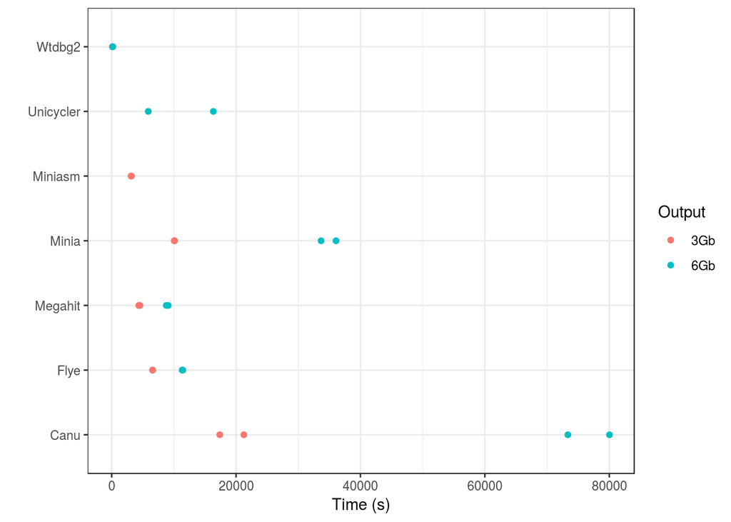

```r
library(ggplot2)
p <- ggplot(d.fig1, aes(x = Time, y = Assembler)) + geom_point(aes(colour = Output)) + xlab("Time (s)") + ylab("")
p = p + theme_bw()
p
```

### CONTIGS - LONG-READS

Como aquí tenemos grandes diferencias entre los short-reads y long-reads, me va a tocar separar los gráficos en dos partes.

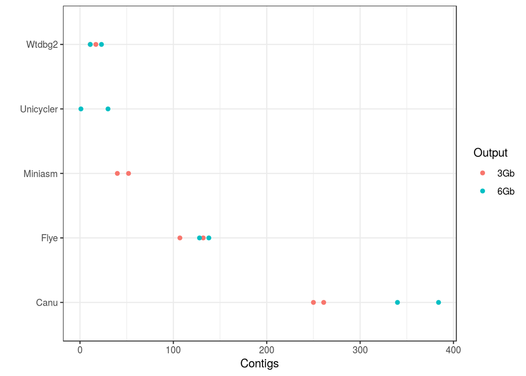

```r
library(ggplot2)
p2 <- ggplot(d.fig1[d.fig1$Length == "Long-reads", ], aes(x = Contigs, y = Assembler)) + geom_point(aes(colour = Output)) + ylab("")
p2 = p2 + theme_bw()
p2
```

### CONTIGS - SHORT-READS

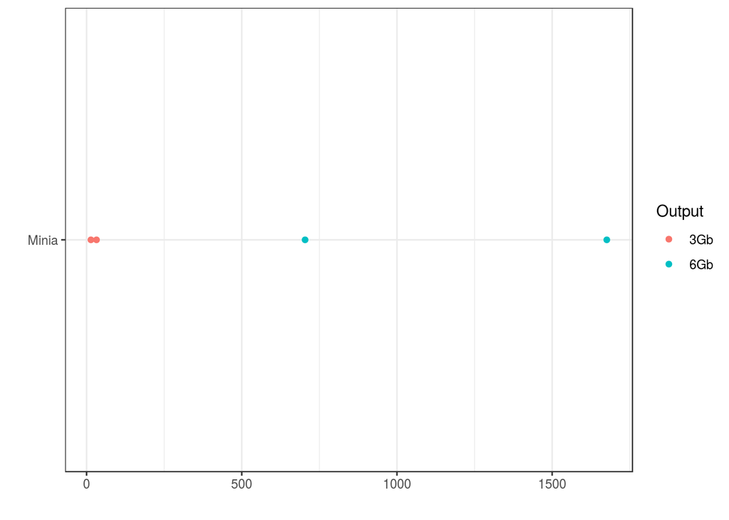

```r
library(ggplot2)
p2.1 <- ggplot(d.fig1[d.fig1$Assembler == "Minia", ], aes(x = Contigs, y = Assembler)) + geom_point(aes(colour = Output)) + ylab("") + xlab("")
p2.1 = p2.1 + theme_bw()
p2.1
```

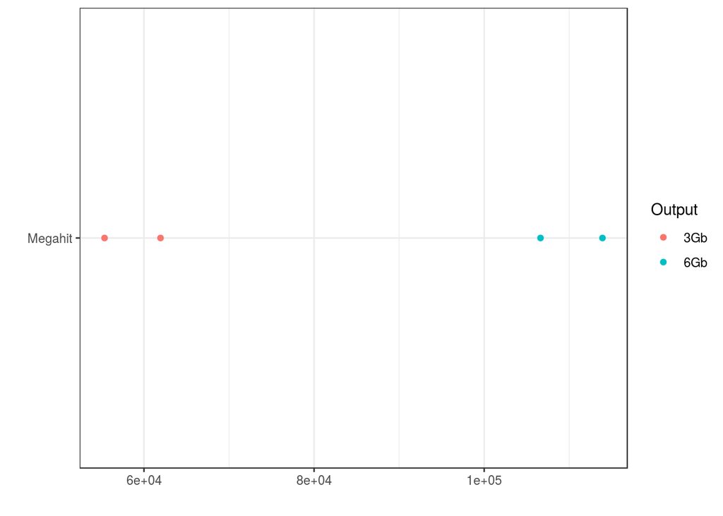

```r
library(ggplot2)
p2.2 <- ggplot(d.fig1[d.fig1$Assembler == "Megahit", ], aes(x = Contigs, y = Assembler)) + geom_point(aes(colour = Output)) + ylab("") + xlab("")
p2.2 = p2.2 + theme_bw()
p2.2
```

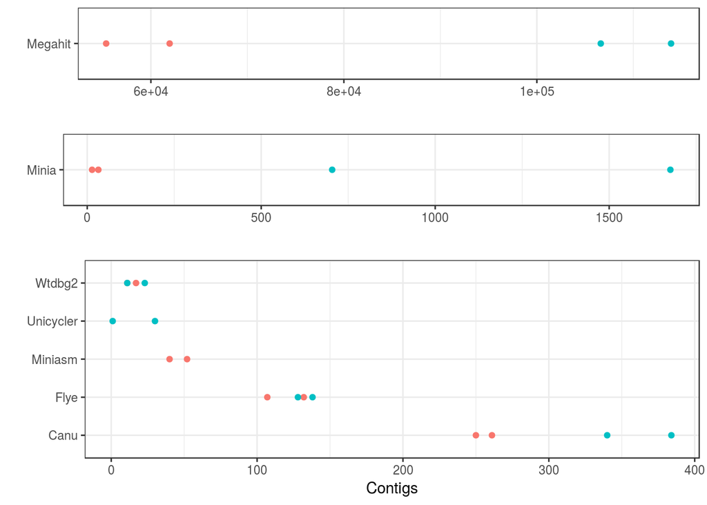

```r
library(gridExtra)
p2.f = ggarrange(p2.2, p2.1, p2,
          legend = FALSE, heights = c(1,1,2),
          ncol = 1, nrow = 3)
p2.f
```

### N50

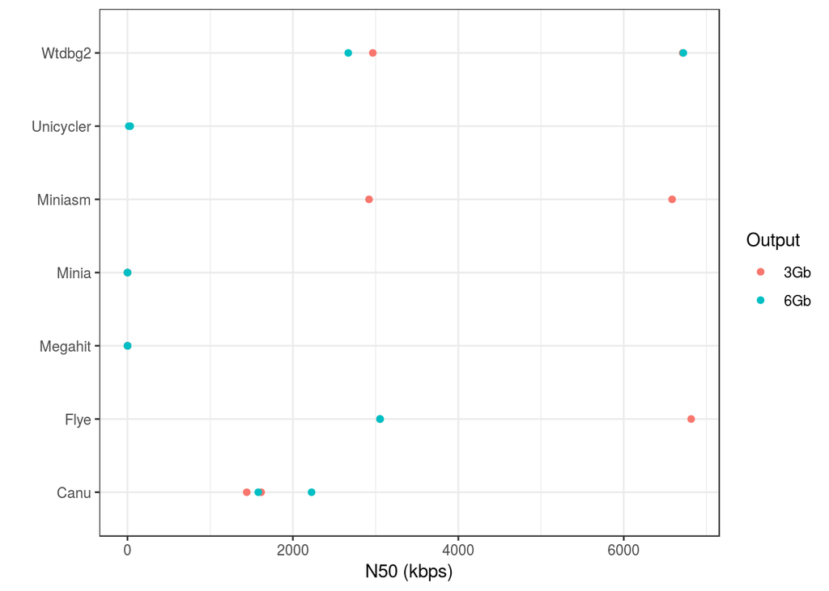

```r
library(ggplot2)
p3 <- ggplot(d.fig1, aes(x = N50, y = Assembler)) + geom_point(aes(colour = Output)) + xlab("N50 (kbps)") + ylab("")
p3 = p3 + theme_bw()
p3
```

### L50

Como aquí tenemos grandes diferencias entre los short-reads y long-reads, me va a tocar separar los gráficos en dos partes.

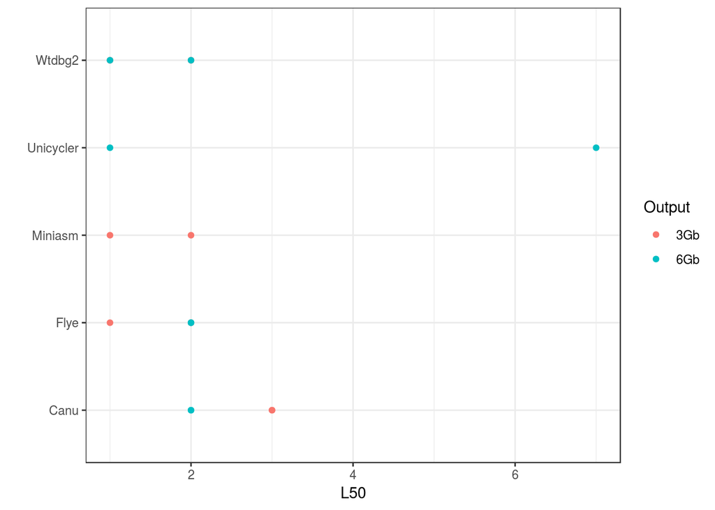

```r
library(ggplot2)
p4 <- ggplot(d.fig1[d.fig1$Length == "Long-reads", ], aes(x = L50, y = Assembler)) + geom_point(aes(colour = Output)) + ylab("")
p4 = p4 + theme_bw()
p4
```

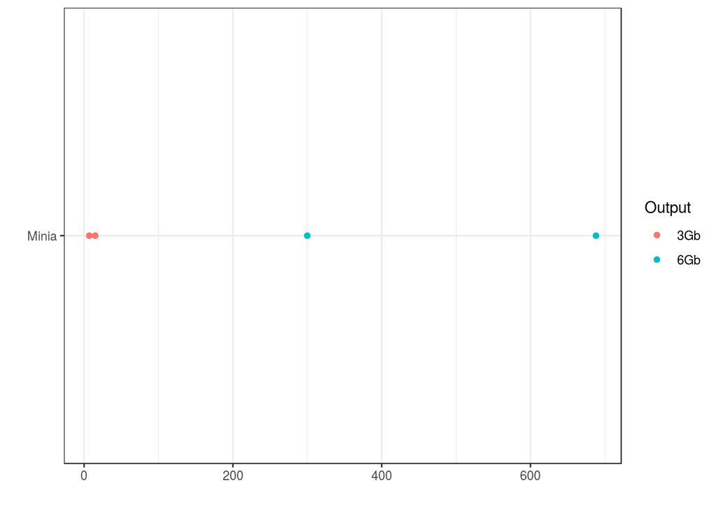

```r
library(ggplot2)
p4.1 <- ggplot(d.fig1[d.fig1$Assembler == "Minia", ], aes(x = L50, y = Assembler)) + geom_point(aes(colour = Output)) + ylab("") + xlab("")
p4.1 = p4.1 + theme_bw()
p4.1
```

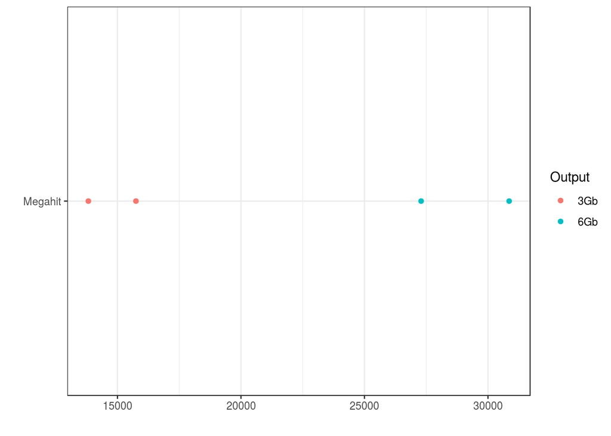

```r
library(ggplot2)
p4.2 <- ggplot(d.fig1[d.fig1$Assembler == "Megahit", ], aes(x = L50, y = Assembler)) + geom_point(aes(colour = Output)) + ylab("") + xlab("")
p4.2 = p4.2 + theme_bw()
p4.2
```

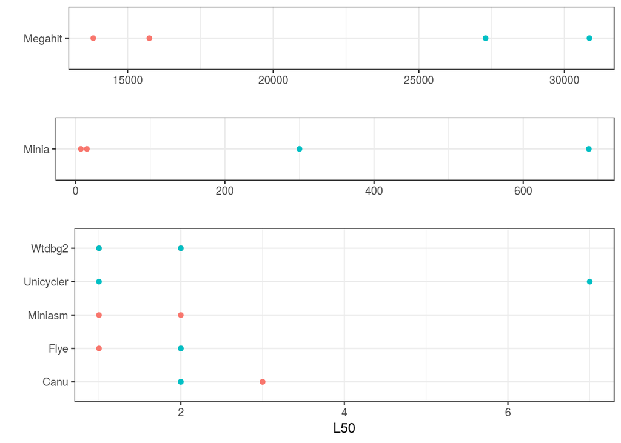

```r
library(gridExtra)
p4.f = ggarrange(p4.2, p4.1, p4,
          legend = FALSE, heights = c(1,1,2),
          ncol = 1, nrow = 3)
p4.f
```

## FIGURA 1

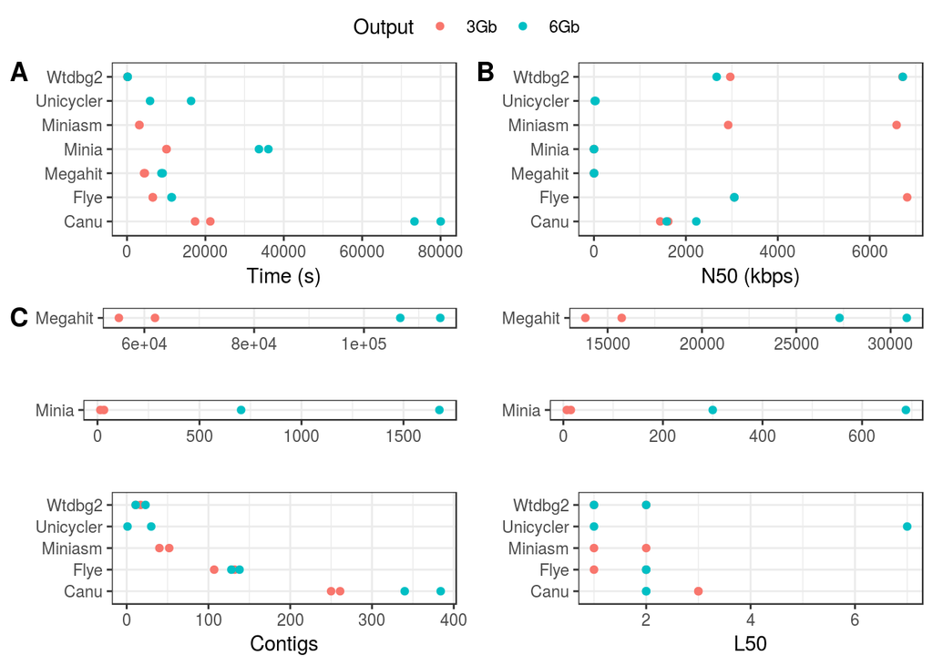

```r
library(ggpubr)
fig1 = ggarrange(p, p3, p2.f, p4.f,
          labels = c("A", "B", "C"), common.legend = TRUE, heights = c(1, 1.5),
          ncol = 2, nrow = 2)
fig1
```

# FIGURE 3

### Genome Fraction

```r
d.fig2.1 = read.csv2(file = "./genome_fraction.csv", header = TRUE, sep = ",", dec = ".")
d.fig2.1
```

Creo que lo voy a separar en 3 y 6 Gbps porque si no va a ser demasiado. Quizás aquí sí que convenga usar un grid.

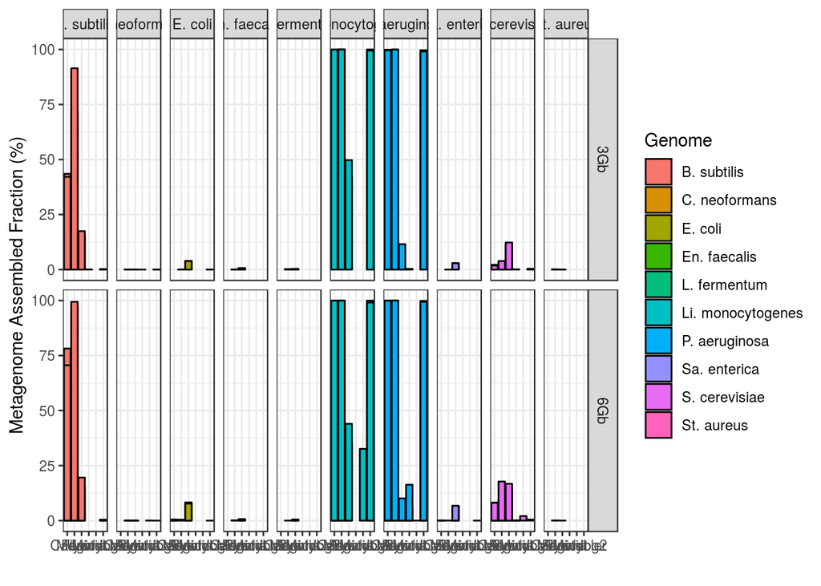

```r
p <- ggplot(data=d.fig2.1, aes(x=Assembler, y=Fraction, fill=Genome)) +
  geom_bar(stat="identity", color="black", position=position_dodge()) +
  theme_bw() + ylab("Metagenome Assembled Fraction (%)") + xlab("") + expand_limits(y=c(0, 100)) + facet_grid(rows =
                                                                                                          vars(Output),
                                                                                                          cols =
                                                                                                          vars(Genome))
p
```

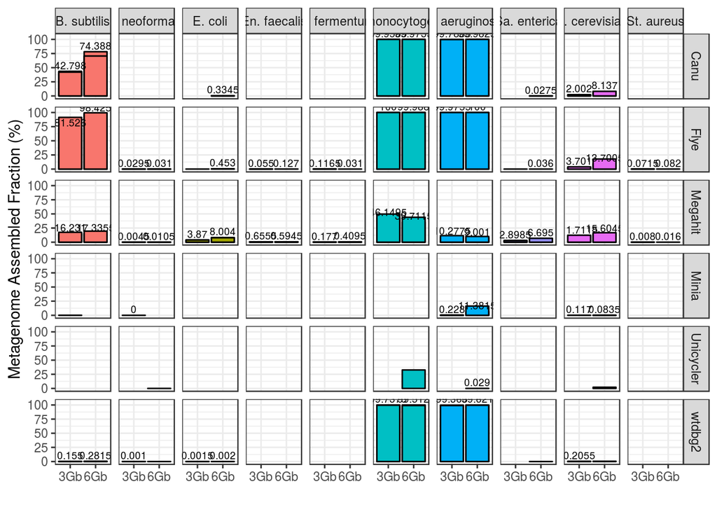

```r
p <- ggplot(data=d.fig2.1, aes(x=Output, y=Fraction, fill=Genome)) +
  geom_bar(stat="identity", color="black", position=position_dodge(), show.legend = FALSE) +
  theme_bw() + ylab("Metagenome Assembled Fraction (%)") + xlab("") + expand_limits(y=c(0, 105)) +
  facet_grid(rows = vars(Assembler), cols = vars(Genome)) +
  geom_text(aes(label=Mean_Fraction), vjust=-0.3, color="black", size=2.5)
p
```

# FIGURE 5 - SNPs

### SNPs - bcftools and MuMmer

```r
d.fig5 = read.csv2(file = "./Fig5_snps.csv", header = TRUE, sep = ",", dec = ".")
d.fig5
```

bcftools

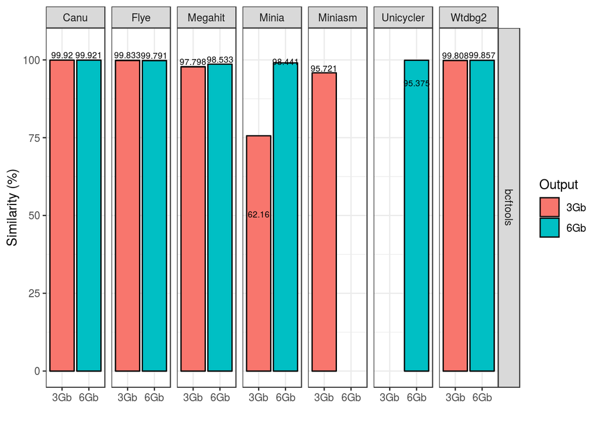

```r
p <- ggplot(data=d.fig5, aes(x=Output, y=bcftools, fill=Output)) +
  geom_bar(stat="identity", color="black", position=position_dodge()) +
  theme_bw() + ylab("Similarity (%)") + xlab("") + expand_limits(y=c(0, 105)) +
  facet_grid(rows = vars(Label_bcftools), cols = vars(Assembler)) +
  geom_text(aes(label=mean_bcftools), vjust=-0.3, color="black", size=2.5)
p
```

MuMmer

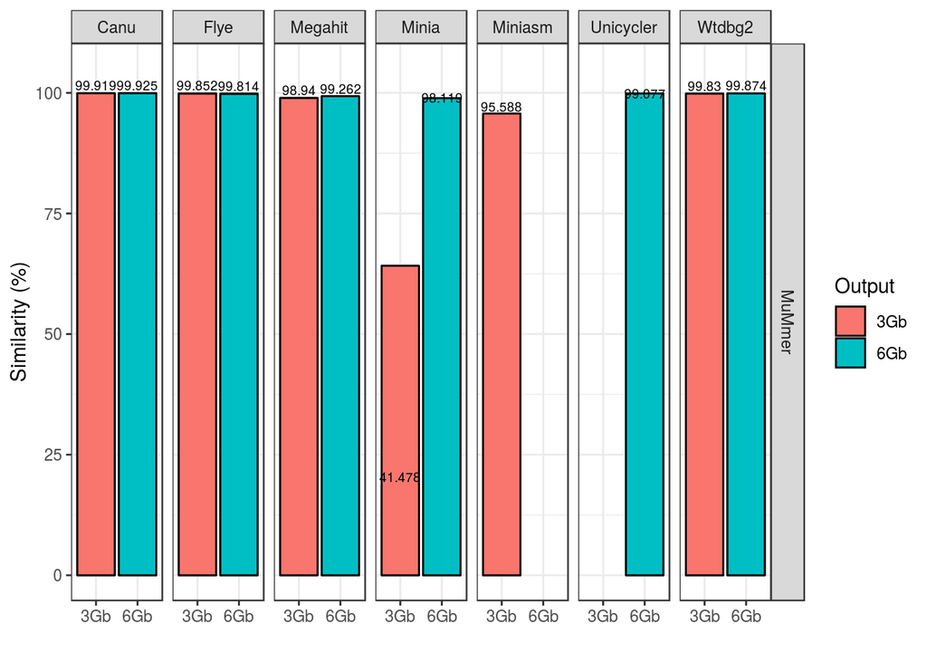

```r
p2 <- ggplot(data=d.fig5, aes(x=Output, y=MuMmer, fill=Output)) +
  geom_bar(stat="identity", color="black", position=position_dodge()) +
  theme_bw() + ylab("Similarity (%)") + xlab("") + expand_limits(y=c(0, 105)) +
  facet_grid(rows = vars(Label_MuMmer), cols = vars(Assembler)) +
  geom_text(aes(label=mean_MuMmer), vjust=-0.3, color="black", size=2.5)
p2
```

Juntamos bcftools y MuMmer que van en la misma escala

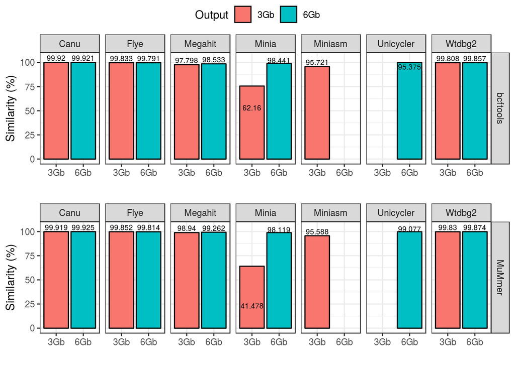

```r
library(ggpubr)
fig5.1 = ggarrange(p, p2, common.legend = TRUE, heights = c(1, 1),
          ncol = 1, nrow = 2, font.label = list(size = 11, face = "bold", color ="black", family = NULL),
          vjust = 1, hjust = -0.2)
fig5.1
```